# 06 - Cutaneous Neurofibroma patient Variables

Sara Gosline

2019-10-08

## Synapse tables with data in them

We have two tables on synapse that have cNF patient data in them - [Patient Table](https://www.synapse.org/#!Synapse:syn7342635/tables/) - [Sample Table](https://www.synapse.org/#!Synapse:syn5556216/tables/)

```r
pat.tab<-synapser::synTableQuery("SELECT Patient,Race,Gender,Age,Pain,Itching FROM syn7342635")$asDataFrame()%>%
  select(-c(ROW_ID,ROW_VERSION))

samp.tab<-synapser::synTableQuery("SELECT Patient,TumorNumber,Length_in_mm FROM syn5556216")$asDataFrame()%>%
  select(-c(ROW_ID,ROW_VERSION))
pat.tab
```

```
##    Patient     Race Gender Age  Pain Itching
## 1        1    White Female  48 FALSE    TRUE
## 2        2    Asian Female  34 FALSE   FALSE
## 3        3 Hispanic Female  48 FALSE   FALSE
## 4        4    White Female  36 FALSE    TRUE
## 5        5    White   Male  65 FALSE   FALSE
## 6        6    White Female  46 FALSE    TRUE
## 7        8    Black Female  27 FALSE   FALSE
## 8        9    White   Male  35 FALSE   FALSE
## 9       10    White   Male  58 FALSE   FALSE
## 10      11    Black Female  30  TRUE    TRUE
## 11      13    White Female  41  TRUE    TRUE
```

```r
samp.tab
```

```
##    Patient TumorNumber Length_in_mm
## 1        1           3           NA
## 2        1           4           14
## 3        1           6           14
## 4        1           9           15
## 5        1           1           15
## 6        1           2           13
## 7        2           4            7
## 8        2           6            6
## 9        2           7            5
## 10       2          10            7
## 11       2           1            5
## 12       2           2            7
## 13       2           8            9
## 14       2           9            7
```

[output cut: 54 more lines]

For the purposes of this analysis we want to have just the age, sex, tumor size and and ‘reformed’ patient name

```r
full.tab<-samp.tab%>%left_join(pat.tab,by='Patient')%>%
  mutate(specimenID=paste0('patient',Patient,'tumor',TumorNumber))
full.tab
```

```
##    Patient TumorNumber Length_in_mm     Race Gender Age  Pain Itching
## 1        1           3           NA    White Female  48 FALSE    TRUE
## 2        1           4           14    White Female  48 FALSE    TRUE
## 3        1           6           14    White Female  48 FALSE    TRUE
## 4        1           9           15    White Female  48 FALSE    TRUE
## 5        1           1           15    White Female  48 FALSE    TRUE
## 6        1           2           13    White Female  48 FALSE    TRUE
## 7        2           4            7    Asian Female  34 FALSE   FALSE
## 8        2           6            6    Asian Female  34 FALSE   FALSE
## 9        2           7            5    Asian Female  34 FALSE   FALSE
## 10       2          10            7    Asian Female  34 FALSE   FALSE
## 11       2           1            5    Asian Female  34 FALSE   FALSE
## 12       2           2            7    Asian Female  34 FALSE   FALSE
## 13       2           8            9    Asian Female  34 FALSE   FALSE
## 14       2           9            7    Asian Female  34 FALSE   FALSE
```

[output cut: 123 more lines]

Now we can evaluate other things

## Plot the data

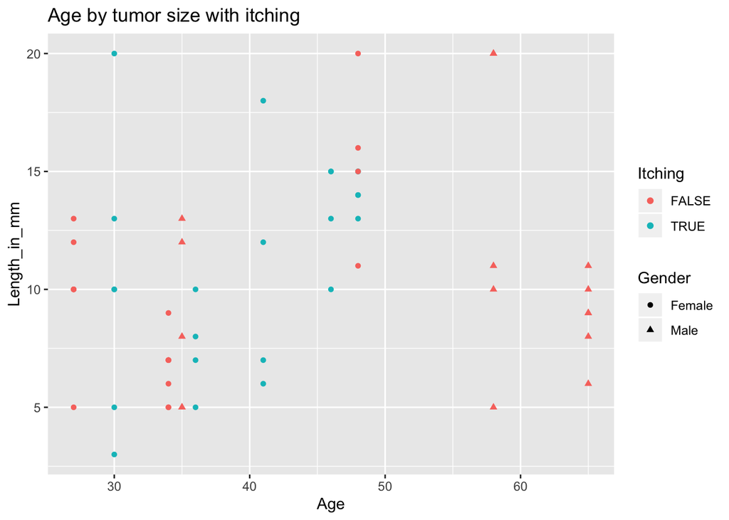

```r
##now what do we see on a tissue level?
require(ggplot2)

p<-ggplot(full.tab)+geom_point(aes(x=Age,y=Length_in_mm,color=Itching,shape=Gender))+ggtitle("Age by tumor size with itching")

print(p)
```

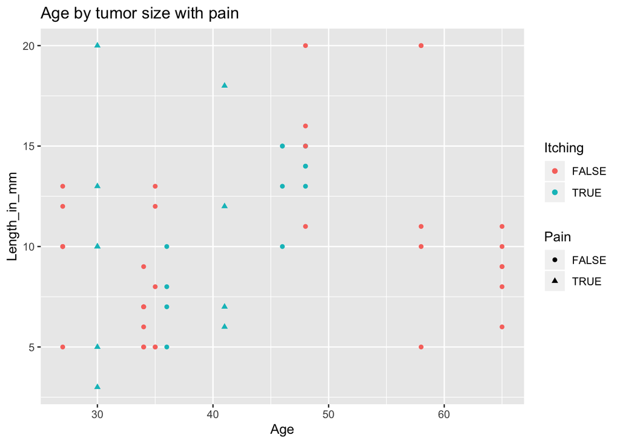

```r
p<-ggplot(full.tab)+geom_point(aes(x=Age,y=Length_in_mm,color=Itching,shape=Pain))+ggtitle("Age by tumor size with pain")
print(p)
```

So the pain/itching variables only go by patient, so we can’t figure out which samples are in pain/itching.

## Get the expression data and see what correlates

```r
exp.data<-synTableQuery('select * from syn20449214 where tumorType=\'Cutaneous Neurofibroma\'')$asDataFrame()

data.with.var<-exp.data%>%left_join(full.tab,by='specimenID')

#now compute the correlation with size for each transcript...?
gene.cors=data.with.var%>%group_by(Symbol)%>%mutate(corVal=cor(zScore,Length_in_mm))

top.genes=select(gene.cors,corVal)%>%distinct()%>%arrange(desc(corVal))%>%select(Symbol)
bottom.genes=select(gene.cors,corVal)%>%distinct()%>%arrange(corVal)%>%select(Symbol)
```

Now we have the genes most correlated with tumor size

```r
top.genes
```

```
## # A tibble: 19,098 x 1
## # Groups:   Symbol [19,098]
##    Symbol
##    <chr>
##  1 AKAP12
##  2 SOCS2
##  3 DAPK2
##  4 SVEP1
##  5 RGL1
##  6 DTX4
##  7 HOXB3
##  8 ADAMTS5
##  9 VPS35L
## 10 ABI3BP
## # … with 19,088 more rows
```

and the genes least correlated

```r
bottom.genes
```

```
## # A tibble: 19,098 x 1
## # Groups:   Symbol [19,098]
##    Symbol
##    <chr>
##  1 DAPL1
##  2 BPNT1
##  3 GSKIP
##  4 RPUSD3
##  5 ZNF707
##  6 IGHMBP2
##  7 WDR12
##  8 IPO13
##  9 MARCH9
## 10 SP6
## # … with 19,088 more rows
```

Now what do these look like?

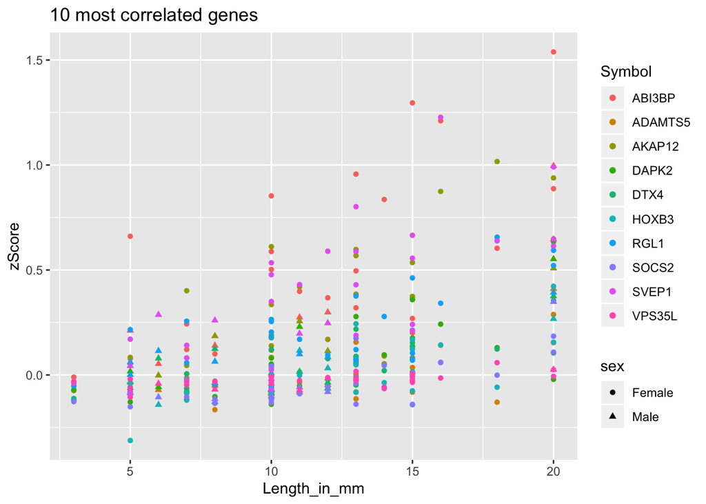

```r
ggplot(subset(data.with.var,Symbol%in%c(top.genes$Symbol[1:10])))+geom_point(aes(x=Length_in_mm,y=zScore,col=Symbol,shape=sex))+ggtitle('10 most correlated genes')
```

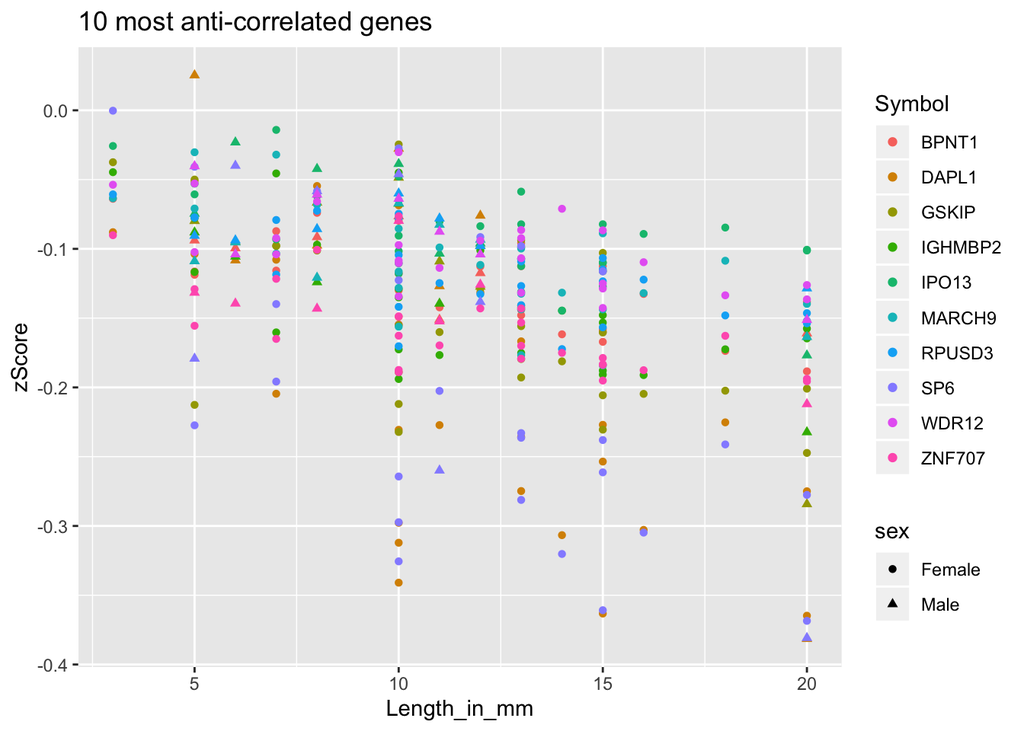

```r
ggplot(subset(data.with.var,Symbol%in%c(bottom.genes$Symbol[1:10])))+geom_point(aes(x=Length_in_mm,y=zScore,col=Symbol,shape=sex))+ggtitle('10 most anti-correlated genes')
```

We should do pathway enrichment of these genes, see if they are doing anything. The fact that HOXB3 is there is already interesting. What else could there be???

## Next steps

I think this is actually pretty cool - we can try to identify which are the ‘driving’ genes of cNF growth. * What pathways are enriched in these genes? * Are these correlations statistically significant? * Are there differences in correlated genes b/w male and female patients? * What are these genes doing in pNFs and MPNSTs? * Are any of these correlated with immune reponse (conversely are immune signatures correlated with this size variable)?

Are there other questions we can answer?